# Case study: How Does a Bike-Share Navigate Speedy Success?

Bhaskar Sutar

2022-10-26

### Introduction

This exploratory analysis case study is towards Capstome project requirement for Google Data Analytics Professional Certificate. The case study involves a bikeshare company’s data of its customer’s trip details over a 12 month period (January 2021 - December 2021). The data has been made available by Motivate International Inc. under this license.

A brief explanation of APPAA:

### Ask

- Ask effective questions
- Define the scope of the analysis
- Define what success looks like

### Prepare

- Verify data’s integrity
- Check data credibility and reliability
- Check data types
- Merge datasets

### Process

- Clean, Remove and Transform data
- Document cleaning processes and results

### Analyze

- Identify patterns
- Draw conclusions
- Make predictions

### Share

- Create effective visuals
- Create a story for data
- Share insights to stakeholders

### Act

- Give recommendations based on insights
- Solve problems
- Create something new

## 1. Ask

#### Scenario

Marketing team needs to design marketing strategies aimed at converting casual riders into annual members. In order to do that, however, the marketing analyst team needs to better understand how annual members and casual riders differ

### Stakeholders:

- Director of marketing
- Cyclistic executive team

#### Objective

Hence, the objective for this analysis is to throw some light on how the two types of customers: annual members and casual riders, use Cyclistic bikeshare differently, based on few parameters that can be calculated/ obtained from existing data.

#### Deliverables:

- Insights on how annual members and casual riders use Cyclistic bikes differently
- Provide effective visuals and relevant data to support insights
- Use insights to give three recommendations to convert casual riders to member riders

## 2. Prepare

#### Data Sources

A total of 12 datasets have been made available for each month starting from January 2021 to December 2021. Each dataset captures the details of every ride logged by the customers of Cyclistic. This data that has been made publicly available has been scrubbed to omit rider’s personal information.

#### Documentation, Cleaning and Preparation of data for analysis

The combined size of all the 12 datasets is close to 1 GB. Data cleaning in spreadsheets will be time-consuming and slow compared to SQL or R. I am choosing R simply because I could do both data wrangling and analysis/ visualizations in the same platform. It is also an opportunity for me to learn R better.

```r
library(tidyverse)
```

```r
library(ggplot2)
library(lubridate)
library(dplyr)
library(readr)
library(janitor)
library(data.table)
library(tidyr)
```

#### Load datasets

```r
trip21_Jan <- read_csv("D:\\files\\202101-divvy-tripdata.csv")
trip21_Feb <- read_csv("D:\\files\\202102-divvy-tripdata.csv")
trip21_Mar <- read_csv("D:\\files\\202103-divvy-tripdata.csv")
trip21_Apr <- read_csv("D:\\files\\202104-divvy-tripdata.csv")
trip21_May <- read_csv("D:\\files\\202105-divvy-tripdata.csv")
trip21_Jun <- read_csv("D:\\files\\202106-divvy-tripdata.csv")
trip21_Jul <- read_csv("D:\\files\\202107-divvy-tripdata.csv")
trip21_Aug <- read_csv("D:\\files\\202108-divvy-tripdata.csv")
trip21_Sep <- read_csv("D:\\files\\202109-divvy-tripdata.csv")
trip21_Oct <- read_csv("D:\\files\\202110-divvy-tripdata.csv")
trip21_Nov <- read_csv("D:\\files\\202111-divvy-tripdata.csv")
trip21_Dec <- read_csv("D:\\files\\202112-divvy-tripdata.csv")
```

#### Check column names of each dataset for consistency

```r
colnames(trip21_Jan)
```

```
##  [1] "ride_id"            "rideable_type"
##  [3] "started_at"         "ended_at"
##  [5] "start_station_name" "start_station_id"
##  [7] "end_station_name"   "end_station_id"
##  [9] "start_lat"          "start_lng"
## [11] "end_lat"            "end_lng"
## [13] "member_casual"
```

```r
colnames(trip21_Feb)
```

```
##  [1] "ride_id"            "rideable_type"
##  [3] "started_at"         "ended_at"
##  [5] "start_station_name" "start_station_id"
##  [7] "end_station_name"   "end_station_id"
##  [9] "start_lat"          "start_lng"
## [11] "end_lat"            "end_lng"
## [13] "member_casual"
```

```r
colnames(trip21_Mar)
```

```
##  [1] "ride_id"            "rideable_type"
##  [3] "started_at"         "ended_at"
##  [5] "start_station_name" "start_station_id"
##  [7] "end_station_name"   "end_station_id"
##  [9] "start_lat"          "start_lng"
## [11] "end_lat"            "end_lng"
## [13] "member_casual"
```

```r
colnames(trip21_Apr)
```

```
##  [1] "ride_id"            "rideable_type"
##  [3] "started_at"         "ended_at"
##  [5] "start_station_name" "start_station_id"
##  [7] "end_station_name"   "end_station_id"
##  [9] "start_lat"          "start_lng"
## [11] "end_lat"            "end_lng"
## [13] "member_casual"
```

```r
colnames(trip21_May)
```

```
##  [1] "ride_id"            "rideable_type"
##  [3] "started_at"         "ended_at"
##  [5] "start_station_name" "start_station_id"
##  [7] "end_station_name"   "end_station_id"
##  [9] "start_lat"          "start_lng"
## [11] "end_lat"            "end_lng"
## [13] "member_casual"
```

```r
colnames(trip21_Jun)
```

```
##  [1] "ride_id"            "rideable_type"
##  [3] "started_at"         "ended_at"
##  [5] "start_station_name" "start_station_id"
##  [7] "end_station_name"   "end_station_id"
##  [9] "start_lat"          "start_lng"
## [11] "end_lat"            "end_lng"
## [13] "member_casual"
```

```r
colnames(trip21_Jul)
```

```
##  [1] "ride_id"            "rideable_type"
##  [3] "started_at"         "ended_at"
##  [5] "start_station_name" "start_station_id"
##  [7] "end_station_name"   "end_station_id"
##  [9] "start_lat"          "start_lng"
## [11] "end_lat"            "end_lng"
## [13] "member_casual"
```

```r
colnames(trip21_Aug)
```

```
##  [1] "ride_id"            "rideable_type"
##  [3] "started_at"         "ended_at"
##  [5] "start_station_name" "start_station_id"
##  [7] "end_station_name"   "end_station_id"
##  [9] "start_lat"          "start_lng"
## [11] "end_lat"            "end_lng"
## [13] "member_casual"
```

```r
colnames(trip21_Sep)
```

```
##  [1] "ride_id"            "rideable_type"
##  [3] "started_at"         "ended_at"
##  [5] "start_station_name" "start_station_id"
##  [7] "end_station_name"   "end_station_id"
##  [9] "start_lat"          "start_lng"
## [11] "end_lat"            "end_lng"
## [13] "member_casual"
```

```r
colnames(trip21_Oct)
```

```
##  [1] "ride_id"            "rideable_type"
##  [3] "started_at"         "ended_at"
##  [5] "start_station_name" "start_station_id"
##  [7] "end_station_name"   "end_station_id"
##  [9] "start_lat"          "start_lng"
## [11] "end_lat"            "end_lng"
## [13] "member_casual"
```

```r
colnames(trip21_Nov)
```

```
##  [1] "ride_id"            "rideable_type"
##  [3] "started_at"         "ended_at"
##  [5] "start_station_name" "start_station_id"
##  [7] "end_station_name"   "end_station_id"
##  [9] "start_lat"          "start_lng"
## [11] "end_lat"            "end_lng"
## [13] "member_casual"
```

```r
colnames(trip21_Dec)
```

```
##  [1] "ride_id"            "rideable_type"
##  [3] "started_at"         "ended_at"
##  [5] "start_station_name" "start_station_id"
##  [7] "end_station_name"   "end_station_id"
##  [9] "start_lat"          "start_lng"
## [11] "end_lat"            "end_lng"
## [13] "member_casual"
```

#### Check data structures and data types for all data frames

```r
str(trip21_Jan)
```

```
## spec_tbl_df [96,834 × 13] (S3: spec_tbl_df/tbl_df/tbl/data.frame)
##  $ ride_id           : chr [1:96834] "E19E6F1B8D4C42ED" "DC88F20C2C55F27F" "EC45C94683FE3F27" "4FA453A75AE377DB" ...
##  $ rideable_type     : chr [1:96834] "electric_bike" "electric_bike" "electric_bike" "electric_bike" ...
##  $ started_at        : POSIXct[1:96834], format: "2021-01-23 16:14:19" ...
##  $ ended_at          : POSIXct[1:96834], format: "2021-01-23 16:24:44" ...
##  $ start_station_name: chr [1:96834] "California Ave & Cortez St" "California Ave & Cortez St" "California Ave & Cortez St" "California Ave & Cortez St" ...
##  $ start_station_id  : chr [1:96834] "17660" "17660" "17660" "17660" ...
##  $ end_station_name  : chr [1:96834] NA NA NA NA ...
##  $ end_station_id    : chr [1:96834] NA NA NA NA ...
##  $ start_lat         : num [1:96834] 41.9 41.9 41.9 41.9 41.9 ...
##  $ start_lng         : num [1:96834] -87.7 -87.7 -87.7 -87.7 -87.7 ...
##  $ end_lat           : num [1:96834] 41.9 41.9 41.9 41.9 41.9 ...
##  $ end_lng           : num [1:96834] -87.7 -87.7 -87.7 -87.7 -87.7 ...
##  $ member_casual     : chr [1:96834] "member" "member" "member" "member" ...
##  - attr(*, "spec")=
##   .. cols(
##   ..   ride_id = col_character(),
##   ..   rideable_type = col_character(),
##   ..   started_at = col_datetime(format = ""),
##   ..   ended_at = col_datetime(format = ""),
##   ..   start_station_name = col_character(),
##   ..   start_station_id = col_character(),
##   ..   end_station_name = col_character(),
##   ..   end_station_id = col_character(),
##   ..   start_lat = col_double(),
##   ..   start_lng = col_double(),
##   ..   end_lat = col_double(),
##   ..   end_lng = col_double(),
##   ..   member_casual = col_character()
##   .. )
##  - attr(*, "problems")=<externalptr>
```

```r
str(trip21_Feb)
```

```
## spec_tbl_df [49,622 × 13] (S3: spec_tbl_df/tbl_df/tbl/data.frame)
##  $ ride_id           : chr [1:49622] "89E7AA6C29227EFF" "0FEFDE2603568365" "E6159D746B2DBB91" "B32D3199F1C2E75B" ...
##  $ rideable_type     : chr [1:49622] "classic_bike" "classic_bike" "electric_bike" "classic_bike" ...
##  $ started_at        : POSIXct[1:49622], format: "2021-02-12 16:14:56" ...
##  $ ended_at          : POSIXct[1:49622], format: "2021-02-12 16:21:43" ...
##  $ start_station_name: chr [1:49622] "Glenwood Ave & Touhy Ave" "Glenwood Ave & Touhy Ave" "Clark St & Lake St" "Wood St & Chicago Ave" ...
##  $ start_station_id  : chr [1:49622] "525" "525" "KA1503000012" "637" ...
##  $ end_station_name  : chr [1:49622] "Sheridan Rd & Columbia Ave" "Bosworth Ave & Howard St" "State St & Randolph St" "Honore St & Division St" ...
##  $ end_station_id    : chr [1:49622] "660" "16806" "TA1305000029" "TA1305000034" ...
##  $ start_lat         : num [1:49622] 42 42 41.9 41.9 41.8 ...
##  $ start_lng         : num [1:49622] -87.7 -87.7 -87.6 -87.7 -87.6 ...
##  $ end_lat           : num [1:49622] 42 42 41.9 41.9 41.8 ...
##  $ end_lng           : num [1:49622] -87.7 -87.7 -87.6 -87.7 -87.6 ...
##  $ member_casual     : chr [1:49622] "member" "casual" "member" "member" ...
##  - attr(*, "spec")=
##   .. cols(
##   ..   ride_id = col_character(),
##   ..   rideable_type = col_character(),
##   ..   started_at = col_datetime(format = ""),
##   ..   ended_at = col_datetime(format = ""),
##   ..   start_station_name = col_character(),
##   ..   start_station_id = col_character(),
##   ..   end_station_name = col_character(),
##   ..   end_station_id = col_character(),
##   ..   start_lat = col_double(),
##   ..   start_lng = col_double(),
##   ..   end_lat = col_double(),
##   ..   end_lng = col_double(),
##   ..   member_casual = col_character()
##   .. )
##  - attr(*, "problems")=<externalptr>
```

```r
str(trip21_Mar)
```

```
## spec_tbl_df [228,496 × 13] (S3: spec_tbl_df/tbl_df/tbl/data.frame)
##  $ ride_id           : chr [1:228496] "CFA86D4455AA1030" "30D9DC61227D1AF3" "846D87A15682A284" "994D05AA75A168F2" ...
##  $ rideable_type     : chr [1:228496] "classic_bike" "classic_bike" "classic_bike" "classic_bike" ...
##  $ started_at        : POSIXct[1:228496], format: "2021-03-16 08:32:30" ...
##  $ ended_at          : POSIXct[1:228496], format: "2021-03-16 08:36:34" ...
##  $ start_station_name: chr [1:228496] "Humboldt Blvd & Armitage Ave" "Humboldt Blvd & Armitage Ave" "Shields Ave & 28th Pl" "Winthrop Ave & Lawrence Ave" ...
##  $ start_station_id  : chr [1:228496] "15651" "15651" "15443" "TA1308000021" ...
##  $ end_station_name  : chr [1:228496] "Stave St & Armitage Ave" "Central Park Ave & Bloomingdale Ave" "Halsted St & 35th St" "Broadway & Sheridan Rd" ...
##  $ end_station_id    : chr [1:228496] "13266" "18017" "TA1308000043" "13323" ...
##  $ start_lat         : num [1:228496] 41.9 41.9 41.8 42 42 ...
##  $ start_lng         : num [1:228496] -87.7 -87.7 -87.6 -87.7 -87.7 ...
##  $ end_lat           : num [1:228496] 41.9 41.9 41.8 42 42.1 ...
##  $ end_lng           : num [1:228496] -87.7 -87.7 -87.6 -87.6 -87.7 ...
##  $ member_casual     : chr [1:228496] "casual" "casual" "casual" "casual" ...
##  - attr(*, "spec")=
##   .. cols(
##   ..   ride_id = col_character(),
##   ..   rideable_type = col_character(),
##   ..   started_at = col_datetime(format = ""),
##   ..   ended_at = col_datetime(format = ""),
##   ..   start_station_name = col_character(),
##   ..   start_station_id = col_character(),
##   ..   end_station_name = col_character(),
##   ..   end_station_id = col_character(),
##   ..   start_lat = col_double(),
##   ..   start_lng = col_double(),
##   ..   end_lat = col_double(),
##   ..   end_lng = col_double(),
##   ..   member_casual = col_character()
##   .. )
##  - attr(*, "problems")=<externalptr>
```

```r
str(trip21_Apr)
```

```
## spec_tbl_df [337,230 × 13] (S3: spec_tbl_df/tbl_df/tbl/data.frame)
##  $ ride_id           : chr [1:337230] "6C992BD37A98A63F" "1E0145613A209000" "E498E15508A80BAD" "1887262AD101C604" ...
##  $ rideable_type     : chr [1:337230] "classic_bike" "docked_bike" "docked_bike" "classic_bike" ...
##  $ started_at        : POSIXct[1:337230], format: "2021-04-12 18:25:36" ...
##  $ ended_at          : POSIXct[1:337230], format: "2021-04-12 18:56:55" ...
##  $ start_station_name: chr [1:337230] "State St & Pearson St" "Dorchester Ave & 49th St" "Loomis Blvd & 84th St" "Honore St & Division St" ...
##  $ start_station_id  : chr [1:337230] "TA1307000061" "KA1503000069" "20121" "TA1305000034" ...
##  $ end_station_name  : chr [1:337230] "Southport Ave & Waveland Ave" "Dorchester Ave & 49th St" "Loomis Blvd & 84th St" "Southport Ave & Waveland Ave" ...
##  $ end_station_id    : chr [1:337230] "13235" "KA1503000069" "20121" "13235" ...
##  $ start_lat         : num [1:337230] 41.9 41.8 41.7 41.9 41.7 ...
##  $ start_lng         : num [1:337230] -87.6 -87.6 -87.7 -87.7 -87.7 ...
##  $ end_lat           : num [1:337230] 41.9 41.8 41.7 41.9 41.7 ...
##  $ end_lng           : num [1:337230] -87.7 -87.6 -87.7 -87.7 -87.7 ...
##  $ member_casual     : chr [1:337230] "member" "casual" "casual" "member" ...
##  - attr(*, "spec")=
##   .. cols(
##   ..   ride_id = col_character(),
##   ..   rideable_type = col_character(),
##   ..   started_at = col_datetime(format = ""),
##   ..   ended_at = col_datetime(format = ""),
##   ..   start_station_name = col_character(),
##   ..   start_station_id = col_character(),
##   ..   end_station_name = col_character(),
##   ..   end_station_id = col_character(),
##   ..   start_lat = col_double(),
##   ..   start_lng = col_double(),
##   ..   end_lat = col_double(),
##   ..   end_lng = col_double(),
##   ..   member_casual = col_character()
##   .. )
##  - attr(*, "problems")=<externalptr>
```

```r
str(trip21_May)
```

```
## spec_tbl_df [531,633 × 13] (S3: spec_tbl_df/tbl_df/tbl/data.frame)
##  $ ride_id           : chr [1:531633] "C809ED75D6160B2A" "DD59FDCE0ACACAF3" "0AB83CB88C43EFC2" "7881AC6D39110C60" ...
##  $ rideable_type     : chr [1:531633] "electric_bike" "electric_bike" "electric_bike" "electric_bike" ...
##  $ started_at        : POSIXct[1:531633], format: "2021-05-30 11:58:15" ...
##  $ ended_at          : POSIXct[1:531633], format: "2021-05-30 12:10:39" ...
##  $ start_station_name: chr [1:531633] NA NA NA NA ...
##  $ start_station_id  : chr [1:531633] NA NA NA NA ...
##  $ end_station_name  : chr [1:531633] NA NA NA NA ...
##  $ end_station_id    : chr [1:531633] NA NA NA NA ...
##  $ start_lat         : num [1:531633] 41.9 41.9 41.9 41.9 41.9 ...
##  $ start_lng         : num [1:531633] -87.6 -87.6 -87.7 -87.7 -87.7 ...
##  $ end_lat           : num [1:531633] 41.9 41.8 41.9 41.9 41.9 ...
##  $ end_lng           : num [1:531633] -87.6 -87.6 -87.7 -87.7 -87.7 ...
##  $ member_casual     : chr [1:531633] "casual" "casual" "casual" "casual" ...
##  - attr(*, "spec")=
##   .. cols(
##   ..   ride_id = col_character(),
##   ..   rideable_type = col_character(),
##   ..   started_at = col_datetime(format = ""),
##   ..   ended_at = col_datetime(format = ""),
##   ..   start_station_name = col_character(),
##   ..   start_station_id = col_character(),
##   ..   end_station_name = col_character(),
##   ..   end_station_id = col_character(),
##   ..   start_lat = col_double(),
##   ..   start_lng = col_double(),
##   ..   end_lat = col_double(),
##   ..   end_lng = col_double(),
##   ..   member_casual = col_character()
##   .. )
##  - attr(*, "problems")=<externalptr>
```

```r
str(trip21_Jun)
```

```
## spec_tbl_df [729,595 × 13] (S3: spec_tbl_df/tbl_df/tbl/data.frame)
##  $ ride_id           : chr [1:729595] "99FEC93BA843FB20" "06048DCFC8520CAF" "9598066F68045DF2" "B03C0FE48C412214" ...
##  $ rideable_type     : chr [1:729595] "electric_bike" "electric_bike" "electric_bike" "electric_bike" ...
##  $ started_at        : POSIXct[1:729595], format: "2021-06-13 14:31:28" ...
##  $ ended_at          : POSIXct[1:729595], format: "2021-06-13 14:34:11" ...
##  $ start_station_name: chr [1:729595] NA NA NA NA ...
##  $ start_station_id  : chr [1:729595] NA NA NA NA ...
##  $ end_station_name  : chr [1:729595] NA NA NA NA ...
##  $ end_station_id    : chr [1:729595] NA NA NA NA ...
##  $ start_lat         : num [1:729595] 41.8 41.8 41.8 41.8 41.8 ...
##  $ start_lng         : num [1:729595] -87.6 -87.6 -87.6 -87.6 -87.6 ...
##  $ end_lat           : num [1:729595] 41.8 41.8 41.8 41.8 41.8 ...
##  $ end_lng           : num [1:729595] -87.6 -87.6 -87.6 -87.6 -87.6 ...
##  $ member_casual     : chr [1:729595] "member" "member" "member" "member" ...
##  - attr(*, "spec")=
##   .. cols(
##   ..   ride_id = col_character(),
##   ..   rideable_type = col_character(),
##   ..   started_at = col_datetime(format = ""),
##   ..   ended_at = col_datetime(format = ""),
##   ..   start_station_name = col_character(),
##   ..   start_station_id = col_character(),
##   ..   end_station_name = col_character(),
##   ..   end_station_id = col_character(),
##   ..   start_lat = col_double(),
##   ..   start_lng = col_double(),
##   ..   end_lat = col_double(),
##   ..   end_lng = col_double(),
##   ..   member_casual = col_character()
##   .. )
##  - attr(*, "problems")=<externalptr>
```

```r
str(trip21_Jul)
```

```
## spec_tbl_df [822,410 × 13] (S3: spec_tbl_df/tbl_df/tbl/data.frame)
##  $ ride_id           : chr [1:822410] "0A1B623926EF4E16" "B2D5583A5A5E76EE" "6F264597DDBF427A" "379B58EAB20E8AA5" ...
##  $ rideable_type     : chr [1:822410] "docked_bike" "classic_bike" "classic_bike" "classic_bike" ...
##  $ started_at        : POSIXct[1:822410], format: "2021-07-02 14:44:36" ...
##  $ ended_at          : POSIXct[1:822410], format: "2021-07-02 15:19:58" ...
##  $ start_station_name: chr [1:822410] "Michigan Ave & Washington St" "California Ave & Cortez St" "Wabash Ave & 16th St" "California Ave & Cortez St" ...
##  $ start_station_id  : chr [1:822410] "13001" "17660" "SL-012" "17660" ...
##  $ end_station_name  : chr [1:822410] "Halsted St & North Branch St" "Wood St & Hubbard St" "Rush St & Hubbard St" "Carpenter St & Huron St" ...
##  $ end_station_id    : chr [1:822410] "KA1504000117" "13432" "KA1503000044" "13196" ...
##  $ start_lat         : num [1:822410] 41.9 41.9 41.9 41.9 41.9 ...
##  $ start_lng         : num [1:822410] -87.6 -87.7 -87.6 -87.7 -87.7 ...
##  $ end_lat           : num [1:822410] 41.9 41.9 41.9 41.9 41.9 ...
##  $ end_lng           : num [1:822410] -87.6 -87.7 -87.6 -87.7 -87.7 ...
##  $ member_casual     : chr [1:822410] "casual" "casual" "member" "member" ...
##  - attr(*, "spec")=
##   .. cols(
##   ..   ride_id = col_character(),
##   ..   rideable_type = col_character(),
##   ..   started_at = col_datetime(format = ""),
##   ..   ended_at = col_datetime(format = ""),
##   ..   start_station_name = col_character(),
##   ..   start_station_id = col_character(),
##   ..   end_station_name = col_character(),
##   ..   end_station_id = col_character(),
##   ..   start_lat = col_double(),
##   ..   start_lng = col_double(),
##   ..   end_lat = col_double(),
##   ..   end_lng = col_double(),
##   ..   member_casual = col_character()
##   .. )
##  - attr(*, "problems")=<externalptr>
```

```r
str(trip21_Aug)
```

```
## spec_tbl_df [804,352 × 13] (S3: spec_tbl_df/tbl_df/tbl/data.frame)
##  $ ride_id           : chr [1:804352] "99103BB87CC6C1BB" "EAFCCCFB0A3FC5A1" "9EF4F46C57AD234D" "5834D3208BFAF1DA" ...
##  $ rideable_type     : chr [1:804352] "electric_bike" "electric_bike" "electric_bike" "electric_bike" ...
##  $ started_at        : POSIXct[1:804352], format: "2021-08-10 17:15:49" ...
##  $ ended_at          : POSIXct[1:804352], format: "2021-08-10 17:22:44" ...
##  $ start_station_name: chr [1:804352] NA NA NA NA ...
##  $ start_station_id  : chr [1:804352] NA NA NA NA ...
##  $ end_station_name  : chr [1:804352] NA NA NA NA ...
##  $ end_station_id    : chr [1:804352] NA NA NA NA ...
##  $ start_lat         : num [1:804352] 41.8 41.8 42 42 41.8 ...
##  $ start_lng         : num [1:804352] -87.7 -87.7 -87.7 -87.7 -87.6 ...
##  $ end_lat           : num [1:804352] 41.8 41.8 42 42 41.8 ...
##  $ end_lng           : num [1:804352] -87.7 -87.6 -87.7 -87.7 -87.6 ...
##  $ member_casual     : chr [1:804352] "member" "member" "member" "member" ...
##  - attr(*, "spec")=
##   .. cols(
##   ..   ride_id = col_character(),
##   ..   rideable_type = col_character(),
##   ..   started_at = col_datetime(format = ""),
##   ..   ended_at = col_datetime(format = ""),
##   ..   start_station_name = col_character(),
##   ..   start_station_id = col_character(),
##   ..   end_station_name = col_character(),
##   ..   end_station_id = col_character(),
##   ..   start_lat = col_double(),
##   ..   start_lng = col_double(),
##   ..   end_lat = col_double(),
##   ..   end_lng = col_double(),
##   ..   member_casual = col_character()
##   .. )
##  - attr(*, "problems")=<externalptr>
```

```r
str(trip21_Sep)
```

```
## spec_tbl_df [756,147 × 13] (S3: spec_tbl_df/tbl_df/tbl/data.frame)
##  $ ride_id           : chr [1:756147] "9DC7B962304CBFD8" "F930E2C6872D6B32" "6EF72137900BB910" "78D1DE133B3DBF55" ...
##  $ rideable_type     : chr [1:756147] "electric_bike" "electric_bike" "electric_bike" "electric_bike" ...
##  $ started_at        : POSIXct[1:756147], format: "2021-09-28 16:07:10" ...
##  $ ended_at          : POSIXct[1:756147], format: "2021-09-28 16:09:54" ...
##  $ start_station_name: chr [1:756147] NA NA NA NA ...
##  $ start_station_id  : chr [1:756147] NA NA NA NA ...
##  $ end_station_name  : chr [1:756147] NA NA NA NA ...
##  $ end_station_id    : chr [1:756147] NA NA NA NA ...
##  $ start_lat         : num [1:756147] 41.9 41.9 41.8 41.8 41.9 ...
##  $ start_lng         : num [1:756147] -87.7 -87.6 -87.7 -87.7 -87.7 ...
##  $ end_lat           : num [1:756147] 41.9 42 41.8 41.8 41.9 ...
##  $ end_lng           : num [1:756147] -87.7 -87.7 -87.7 -87.7 -87.7 ...
##  $ member_casual     : chr [1:756147] "casual" "casual" "casual" "casual" ...
##  - attr(*, "spec")=
##   .. cols(
##   ..   ride_id = col_character(),
##   ..   rideable_type = col_character(),
##   ..   started_at = col_datetime(format = ""),
##   ..   ended_at = col_datetime(format = ""),
##   ..   start_station_name = col_character(),
##   ..   start_station_id = col_character(),
##   ..   end_station_name = col_character(),
##   ..   end_station_id = col_character(),
##   ..   start_lat = col_double(),
##   ..   start_lng = col_double(),
##   ..   end_lat = col_double(),
##   ..   end_lng = col_double(),
##   ..   member_casual = col_character()
##   .. )
##  - attr(*, "problems")=<externalptr>
```

```r
str(trip21_Oct)
```

```
## spec_tbl_df [631,226 × 13] (S3: spec_tbl_df/tbl_df/tbl/data.frame)
##  $ ride_id           : chr [1:631226] "620BC6107255BF4C" "4471C70731AB2E45" "26CA69D43D15EE14" "362947F0437E1514" ...
##  $ rideable_type     : chr [1:631226] "electric_bike" "electric_bike" "electric_bike" "electric_bike" ...
##  $ started_at        : POSIXct[1:631226], format: "2021-10-22 12:46:42" ...
##  $ ended_at          : POSIXct[1:631226], format: "2021-10-22 12:49:50" ...
##  $ start_station_name: chr [1:631226] "Kingsbury St & Kinzie St" NA NA NA ...
##  $ start_station_id  : chr [1:631226] "KA1503000043" NA NA NA ...
##  $ end_station_name  : chr [1:631226] NA NA NA NA ...
##  $ end_station_id    : chr [1:631226] NA NA NA NA ...
##  $ start_lat         : num [1:631226] 41.9 41.9 41.9 41.9 41.9 ...
##  $ start_lng         : num [1:631226] -87.6 -87.7 -87.7 -87.7 -87.7 ...
##  $ end_lat           : num [1:631226] 41.9 41.9 41.9 41.9 41.9 ...
##  $ end_lng           : num [1:631226] -87.6 -87.7 -87.7 -87.7 -87.7 ...
##  $ member_casual     : chr [1:631226] "member" "member" "member" "member" ...
##  - attr(*, "spec")=
##   .. cols(
##   ..   ride_id = col_character(),
##   ..   rideable_type = col_character(),
##   ..   started_at = col_datetime(format = ""),
##   ..   ended_at = col_datetime(format = ""),
##   ..   start_station_name = col_character(),
##   ..   start_station_id = col_character(),
##   ..   end_station_name = col_character(),
##   ..   end_station_id = col_character(),
##   ..   start_lat = col_double(),
##   ..   start_lng = col_double(),
##   ..   end_lat = col_double(),
##   ..   end_lng = col_double(),
##   ..   member_casual = col_character()
##   .. )
##  - attr(*, "problems")=<externalptr>
```

```r
str(trip21_Nov)
```

```
## spec_tbl_df [359,978 × 13] (S3: spec_tbl_df/tbl_df/tbl/data.frame)
##  $ ride_id           : chr [1:359978] "7C00A93E10556E47" "90854840DFD508BA" "0A7D10CDD144061C" "2F3BE33085BCFF02" ...
##  $ rideable_type     : chr [1:359978] "electric_bike" "electric_bike" "electric_bike" "electric_bike" ...
##  $ started_at        : POSIXct[1:359978], format: "2021-11-27 13:27:38" ...
##  $ ended_at          : POSIXct[1:359978], format: "2021-11-27 13:46:38" ...
##  $ start_station_name: chr [1:359978] NA NA NA NA ...
##  $ start_station_id  : chr [1:359978] NA NA NA NA ...
##  $ end_station_name  : chr [1:359978] NA NA NA NA ...
##  $ end_station_id    : chr [1:359978] NA NA NA NA ...
##  $ start_lat         : num [1:359978] 41.9 42 42 41.9 41.9 ...
##  $ start_lng         : num [1:359978] -87.7 -87.7 -87.7 -87.8 -87.6 ...
##  $ end_lat           : num [1:359978] 42 41.9 42 41.9 41.9 ...
##  $ end_lng           : num [1:359978] -87.7 -87.7 -87.7 -87.8 -87.6 ...
##  $ member_casual     : chr [1:359978] "casual" "casual" "casual" "casual" ...
##  - attr(*, "spec")=
##   .. cols(
##   ..   ride_id = col_character(),
##   ..   rideable_type = col_character(),
##   ..   started_at = col_datetime(format = ""),
##   ..   ended_at = col_datetime(format = ""),
##   ..   start_station_name = col_character(),
##   ..   start_station_id = col_character(),
##   ..   end_station_name = col_character(),
##   ..   end_station_id = col_character(),
##   ..   start_lat = col_double(),
##   ..   start_lng = col_double(),
##   ..   end_lat = col_double(),
##   ..   end_lng = col_double(),
##   ..   member_casual = col_character()
##   .. )
##  - attr(*, "problems")=<externalptr>
```

```r
str(trip21_Dec)
```

```
## spec_tbl_df [247,540 × 13] (S3: spec_tbl_df/tbl_df/tbl/data.frame)
##  $ ride_id           : chr [1:247540] "46F8167220E4431F" "73A77762838B32FD" "4CF42452054F59C5" "3278BA87BF698339" ...
##  $ rideable_type     : chr [1:247540] "electric_bike" "electric_bike" "electric_bike" "classic_bike" ...
##  $ started_at        : POSIXct[1:247540], format: "2021-12-07 15:06:07" ...
##  $ ended_at          : POSIXct[1:247540], format: "2021-12-07 15:13:42" ...
##  $ start_station_name: chr [1:247540] "Laflin St & Cullerton St" "LaSalle Dr & Huron St" "Halsted St & North Branch St" "Halsted St & North Branch St" ...
##  $ start_station_id  : chr [1:247540] "13307" "KP1705001026" "KA1504000117" "KA1504000117" ...
##  $ end_station_name  : chr [1:247540] "Morgan St & Polk St" "Clarendon Ave & Leland Ave" "Broadway & Barry Ave" "LaSalle Dr & Huron St" ...
##  $ end_station_id    : chr [1:247540] "TA1307000130" "TA1307000119" "13137" "KP1705001026" ...
##  $ start_lat         : num [1:247540] 41.9 41.9 41.9 41.9 41.9 ...
##  $ start_lng         : num [1:247540] -87.7 -87.6 -87.6 -87.6 -87.7 ...
##  $ end_lat           : num [1:247540] 41.9 42 41.9 41.9 41.9 ...
##  $ end_lng           : num [1:247540] -87.7 -87.7 -87.6 -87.6 -87.6 ...
##  $ member_casual     : chr [1:247540] "member" "casual" "member" "member" ...
##  - attr(*, "spec")=
##   .. cols(
##   ..   ride_id = col_character(),
##   ..   rideable_type = col_character(),
##   ..   started_at = col_datetime(format = ""),
##   ..   ended_at = col_datetime(format = ""),
##   ..   start_station_name = col_character(),
##   ..   start_station_id = col_character(),
##   ..   end_station_name = col_character(),
##   ..   end_station_id = col_character(),
##   ..   start_lat = col_double(),
##   ..   start_lng = col_double(),
##   ..   end_lat = col_double(),
##   ..   end_lng = col_double(),
##   ..   member_casual = col_character()
##   .. )
##  - attr(*, "problems")=<externalptr>
```

#### Combine all the datasets into one single dataframe to consolidate analysis

```r
trips21fill<- rbind(trip21_Jan, trip21_Feb, trip21_Mar, trip21_Apr, trip21_May, trip21_Jun, trip21_Jul, trip21_Aug, trip21_Sep, trip21_Oct, trip21_Nov, trip21_Dec)
```

#### View newly created dataset

```r
View(trips21fill)
```

All looks good!

#### Remove columns not required or beyond the scope of project

```r
trips21fill <- trips21fill %>%
    select(-c(start_lat:end_lng))
glimpse(trips21fill)
```

```
## Rows: 5,595,063
## Columns: 9
## $ ride_id            <chr> "E19E6F1B8D4C42ED", "DC88F20C2C55…
## $ rideable_type      <chr> "electric_bike", "electric_bike",…
## $ started_at         <dttm> 2021-01-23 16:14:19, 2021-01-27 …
## $ ended_at           <dttm> 2021-01-23 16:24:44, 2021-01-27 …
## $ start_station_name <chr> "California Ave & Cortez St", "Ca…
## $ start_station_id   <chr> "17660", "17660", "17660", "17660…
## $ end_station_name   <chr> NA, NA, NA, NA, NA, NA, NA, NA, N…
## $ end_station_id     <chr> NA, NA, NA, NA, NA, NA, NA, NA, N…
## $ member_casual      <chr> "member", "member", "member", "me…
```

Rename columns for better readability

```r
trips21fill <- trips21fill %>%
    rename(ride_type = rideable_type,
           start_time = started_at,
           end_time = ended_at,
           customer_type = member_casual)
glimpse(trips21fill)
```

```
## Rows: 5,595,063
## Columns: 9
## $ ride_id            <chr> "E19E6F1B8D4C42ED", "DC88F20C2C55…
## $ ride_type          <chr> "electric_bike", "electric_bike",…
## $ start_time         <dttm> 2021-01-23 16:14:19, 2021-01-27 …
## $ end_time           <dttm> 2021-01-23 16:24:44, 2021-01-27 …
## $ start_station_name <chr> "California Ave & Cortez St", "Ca…
## $ start_station_id   <chr> "17660", "17660", "17660", "17660…
## $ end_station_name   <chr> NA, NA, NA, NA, NA, NA, NA, NA, N…
## $ end_station_id     <chr> NA, NA, NA, NA, NA, NA, NA, NA, N…
## $ customer_type      <chr> "member", "member", "member", "me…
```

Add new columns that can be used for aggregate functions

```r
#column for day of the week the trip started
trips21fill$day_of_the_week <- format(as.Date(trips21fill$start_time),'%a')

#column for month when the trip started
trips21fill$month <- format(as.Date(trips21fill$start_time),'%b_%y')

#column for time of the day when the trip started
#Time element needs to be extracted from start_time. However, as the times must be in POSIXct
#(only times of class POSIXct are supported in ggplot2), a two-step conversion is needed.
#First the time is converted to a character vector, effectively stripping all the date information.
#The time is then converted back to POSIXct with today’s date – the date is of no interest to us,
#only the hours-minutes-seconds are.
trips21fill$time <- format(trips21fill$start_time, format = "%H:%M")
trips21fill$time <- as.POSIXct(trips21fill$time, format = "%H:%M")

#column for trip duration in min
trips21fill$trip_duration <- (as.double(difftime(trips21fill$end_time, trips21fill$start_time)))/60

# check the dataframe
glimpse(trips21fill)
```

```
## Rows: 5,595,063
## Columns: 13
## $ ride_id            <chr> "E19E6F1B8D4C42ED", "DC88F20C2C55…
## $ ride_type          <chr> "electric_bike", "electric_bike",…
## $ start_time         <dttm> 2021-01-23 16:14:19, 2021-01-27 …
## $ end_time           <dttm> 2021-01-23 16:24:44, 2021-01-27 …
## $ start_station_name <chr> "California Ave & Cortez St", "Ca…
## $ start_station_id   <chr> "17660", "17660", "17660", "17660…
## $ end_station_name   <chr> NA, NA, NA, NA, NA, NA, NA, NA, N…
## $ end_station_id     <chr> NA, NA, NA, NA, NA, NA, NA, NA, N…
## $ customer_type      <chr> "member", "member", "member", "me…
## $ day_of_the_week    <chr> "Sat", "Wed", "Thu", "Thu", "Sat"…
## $ month              <chr> "Jan_21", "Jan_21", "Jan_21", "Ja…
## $ time               <dttm> 2022-10-27 16:14:00, 2022-10-27 …
## $ trip_duration      <dbl> 10.4166667, 4.0666667, 1.3333333,…
```

Let’s check to see if the trip_duration column has any negative values, as this may cause problem while creating visualizations. Also, we do not want to include the trips that were part of quality tests by the company. These trips are usually identified by string ‘test’ in the start_station_name column.

```r
# checking for trip lengths less than 0
nrow(subset(trips21fill,trip_duration < 0))
```

```
## [1] 147
```

```r
#checking for testrides that were made by company for quality checks
nrow(subset(trips21fill, start_station_name %like% "TEST"))
```

```
## [1] 0
```

```r
nrow(subset(trips21fill, start_station_name %like% "test"))
```

```
## [1] 0
```

```r
nrow(subset(trips21fill, start_station_name %like% "Test"))
```

```
## [1] 0
```

As there are 147 rows with trip_dration less than 0 mins. we will remove these observations from our dataframe. We will create a new dataframe deviod of these obseravtions without making any changes to the existing dataframe.

```r
# remove negative trip durations
trips21fill_v2 <- trips21fill[!(trips21fill$trip_duration < 0),]

#check dataframe
glimpse(trips21fill_v2)
```

```
## Rows: 5,594,916
## Columns: 13
## $ ride_id            <chr> "E19E6F1B8D4C42ED", "DC88F20C2C55…
## $ ride_type          <chr> "electric_bike", "electric_bike",…
## $ start_time         <dttm> 2021-01-23 16:14:19, 2021-01-27 …
## $ end_time           <dttm> 2021-01-23 16:24:44, 2021-01-27 …
## $ start_station_name <chr> "California Ave & Cortez St", "Ca…
## $ start_station_id   <chr> "17660", "17660", "17660", "17660…
## $ end_station_name   <chr> NA, NA, NA, NA, NA, NA, NA, NA, N…
## $ end_station_id     <chr> NA, NA, NA, NA, NA, NA, NA, NA, N…
## $ customer_type      <chr> "member", "member", "member", "me…
## $ day_of_the_week    <chr> "Sat", "Wed", "Thu", "Thu", "Sat"…
## $ month              <chr> "Jan_21", "Jan_21", "Jan_21", "Ja…
## $ time               <dttm> 2022-10-27 16:14:00, 2022-10-27 …
## $ trip_duration      <dbl> 10.4166667, 4.0666667, 1.3333333,…
```

It is important to make sure that customer_type column has only two distinct values. Let’s confirm the same.

```r
# checking count of distinct values
table(trips21fill_v2$customer_type)
```

```
##
##  casual  member
## 2528946 3065970
```

```r
#aggregating total trip duration by customer type
setNames(aggregate(trip_duration ~ customer_type, trips21fill_v2, sum), c("customer_type", "total_trip_duration(mins)"))
```

```
##   customer_type total_trip_duration(mins)
## 1        casual                  80931864
## 2        member                  41800052
```

### 4&5. Analyze and Share the Data

The dataframe is now ready for descriptive analysis that will help us uncover some insights on how the casual riders and members use Cyclistic rideshare differently.

First, let’s try to get some simple statistics on trip_duration for all customers, and do the same by customer_type.

```r
# statictical summary of trip_duration for all trips
summary(trips21fill_v2$trip_duration)
```

```
##     Min.  1st Qu.   Median     Mean  3rd Qu.     Max.
##     0.00     6.75    12.00    21.94    21.78 55944.15
```

```r
#statistical summary of trip_duration by customer_type
trips21fill_v2 %>%
    group_by(customer_type) %>%
    summarise(min_trip_duration = min(trip_duration),max_trip_duration = max(trip_duration),
              median_trip_duration = median(trip_duration), mean_trip_duration = mean(trip_duration))
```

```
## # A tibble: 2 × 5
##   customer_type min_trip_duration max_trip_d…¹ media…² mean_…³
##   <chr>                     <dbl>        <dbl>   <dbl>   <dbl>
## 1 casual                        0       55944.    16.0    32.0
## 2 member                        0        1560.     9.6    13.6
## # … with abbreviated variable names ¹max_trip_duration,
## #   ²median_trip_duration, ³mean_trip_duration
```

The mean trip duration of member riders is lower than the mean trip duration of all trips, while it is exactly the opposite for casual riders, whose mean trip duration is higher than the the mean trip duration of all trips. This tells us that casual riders usually take the bikes out for a longer duration compared to members.

Total number of trips by customer type and day of the week

```r
# fix the order for the day_of_the_week and month variable so that they show up
# in the same sequence in output tables and visualizations
trips21fill_v2$day_of_the_week <- ordered(trips21fill_v2$day_of_the_week, levels=c("Mon", "Tue", "Wed", "Thu", "Fri", "Sat", "Sun"))
trips21fill_v2$month <- ordered(trips21fill_v2$month, levels=c("Jan_21", "Feb_21", "Mar_21", "Apr_21", "May_21", "Jun_21", "Jul_21", "Aug_21", "Sep_21", "Oct_21","Nov_21", "Dec_21" ))
trips21fill_v2 %>%
  group_by(customer_type, day_of_the_week) %>%
  summarise(number_of_rides = n(),average_duration_mins = mean(trip_duration)) %>%
  arrange(customer_type, desc(number_of_rides))
```

```
## # A tibble: 14 × 4
## # Groups:   customer_type [2]
##    customer_type day_of_the_week number_of_rides average_dur…¹
##    <chr>         <ord>                     <int>         <dbl>
##  1 casual        Sat                      557994          34.7
##  2 casual        Sun                      481104          37.6
##  3 casual        Fri                      364075          30.3
##  4 casual        Mon                      286373          31.9
##  5 casual        Thu                      286064          27.7
##  6 casual        Wed                      278948          27.7
##  7 casual        Tue                      274388          28.0
##  8 member        Wed                      477156          12.8
##  9 member        Tue                      465509          12.8
## 10 member        Thu                      451520          12.8
## 11 member        Fri                      446423          13.3
## 12 member        Sat                      433041          15.3
## 13 member        Mon                      416204          13.2
## 14 member        Sun                      376117          15.7
## # … with abbreviated variable name ¹average_duration_mins
```

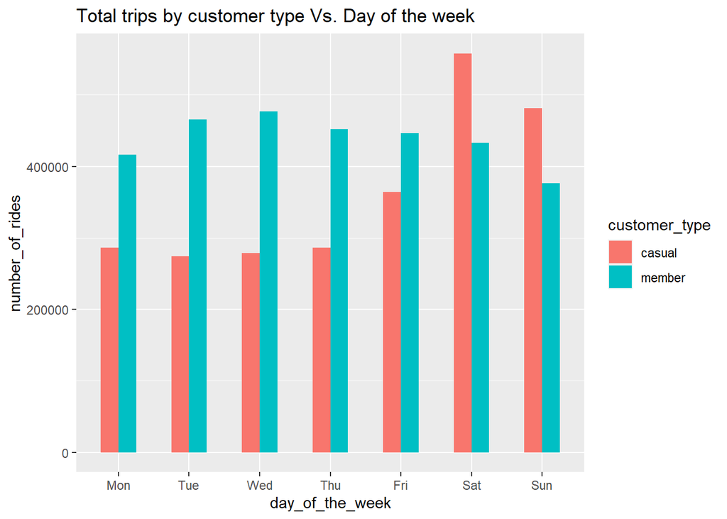

```r
trips21fill_v2 %>%
  group_by(customer_type, day_of_the_week) %>%
  summarise(number_of_rides = n()) %>%
  arrange(customer_type, day_of_the_week)  %>%
  ggplot(aes(x = day_of_the_week, y = number_of_rides, fill = customer_type)) +
  labs(title ="Total trips by customer type Vs. Day of the week") +
  geom_col(width=0.5, position = position_dodge(width=0.5)) +
  scale_y_continuous(labels = function(x) format(x, scientific = FALSE))
```

```r
unique(trips21fill$month)
```

```
##  [1] "Jan_21" "Feb_21" "Mar_21" "Apr_21" "May_21" "Jun_21"
##  [7] "Jul_21" "Aug_21" "Sep_21" "Oct_21" "Nov_21" "Dec_21"
```

```r
trips21fill_v2 %>%
  group_by(customer_type, month) %>%
  summarise(number_of_rides = n(),`average_duration_(mins)` = mean(trip_duration)) %>%
  arrange(customer_type,desc(number_of_rides))
```

```
## # A tibble: 24 × 4
## # Groups:   customer_type [2]
##    customer_type month  number_of_rides average_duration_(mi…¹
##    <chr>         <ord>            <int>                  <dbl>
##  1 casual        Jul_21          442048                   32.8
##  2 casual        Aug_21          412662                   28.8
##  3 casual        Jun_21          370678                   37.1
##  4 casual        Sep_21          363883                   27.8
##  5 casual        Oct_21          257242                   28.7
##  6 casual        May_21          256916                   38.2
##  7 casual        Apr_21          136601                   38.0
##  8 casual        Nov_21          106898                   23.1
##  9 casual        Mar_21           84032                   38.2
## 10 casual        Dec_21           69738                   23.5
## # … with 14 more rows, and abbreviated variable name
## #   ¹`average_duration_(mins)`
```

#### Visualization:

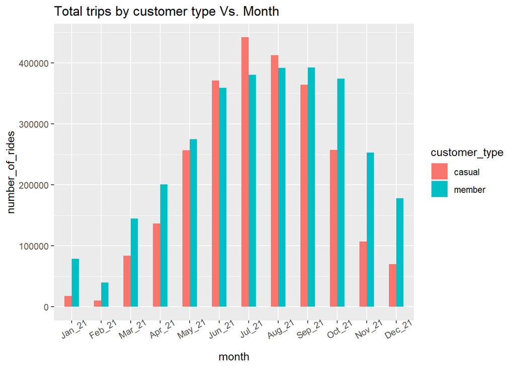

```r
trips21fill_v2 %>%
  group_by(customer_type, month) %>%
  summarise(number_of_rides = n()) %>%
  arrange(customer_type, month)  %>%
  ggplot(aes(x = month, y = number_of_rides, fill = customer_type)) +
  labs(title ="Total trips by customer type Vs. Month") +
  theme(axis.text.x = element_text(angle = 30)) +
  geom_col(width=0.5, position = position_dodge(width=0.5)) +
  scale_y_continuous(labels = function(x) format(x, scientific = FALSE))
```

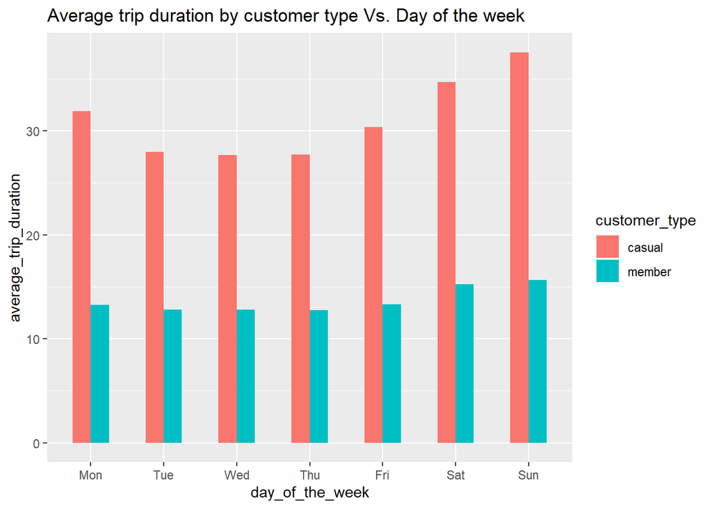

```r
trips21fill_v2 %>%
  group_by(customer_type, day_of_the_week) %>%
  summarise(average_trip_duration = mean(trip_duration)) %>%
  ggplot(aes(x = day_of_the_week, y = average_trip_duration, fill = customer_type)) +
  geom_col(width=0.5, position = position_dodge(width=0.5)) +
  labs(title ="Average trip duration by customer type Vs. Day of the week")
```

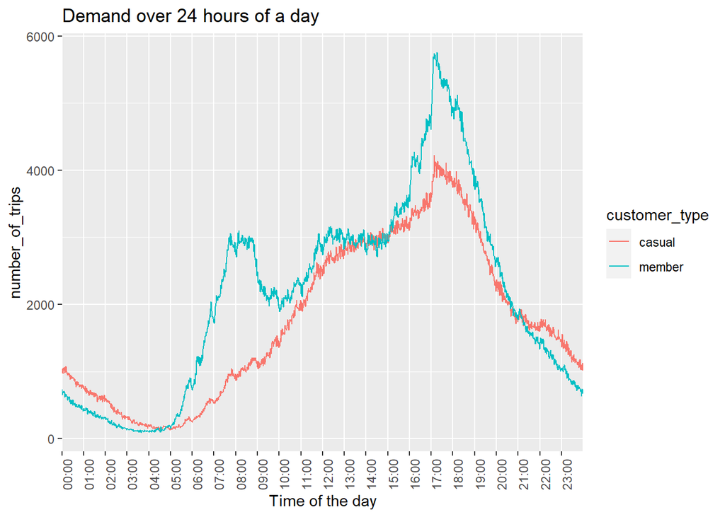

```r
trips21fill_v2 %>%
  group_by(customer_type, time) %>%
  summarise(number_of_trips = n()) %>%
  ggplot(aes(x = time, y = number_of_trips, color = customer_type, group = customer_type)) +
  geom_line() +
  scale_x_datetime(date_breaks = "1 hour", minor_breaks = NULL,
                   date_labels = "%H:%M", expand = c(0,0)) +
  theme(axis.text.x = element_text(angle = 90)) +
  labs(title ="Demand over 24 hours of a day", x = "Time of the day")
```

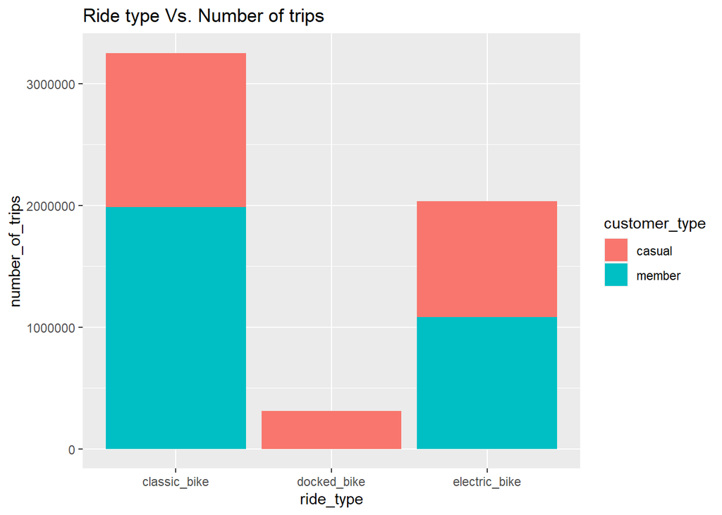

```r
trips21fill_v2 %>%
  group_by(ride_type, customer_type) %>%
  summarise(number_of_trips = n()) %>%
  ggplot(aes(x= ride_type, y=number_of_trips, fill= customer_type))+
              geom_bar(stat='identity') +
  scale_y_continuous(labels = function(x) format(x, scientific = FALSE)) +
  labs(title ="Ride type Vs. Number of trips")
```

Note: Data is not available on the quantity of fleet across each type of bikes.

#### Creating a csv file of the clean data for futher analysis or visualizations in other tools like SQL, Tableau, Power BI, etc.

```r
clean_data <- aggregate(trips21fill_v2$trip_duration ~ trips21fill_v2$customer_type + trips21fill_v2$day_of_the_week, FUN = mean)
write.csv(clean_data, "Clean Data.csv", row.names = F)
```

## 6. Act

#### The average ride time shows a stark difference between the casuals and members. Casuals overall spend more time using the service than their full time member counter-parts.

### what does the data tell us?

### key takeaways

- Casual users tended to ride more so in the warmer months of Chicago, namely June- August. Their participation exceeded that of the long term members.
- To further that the Casual demographic spent on average a lot longer time per ride than their long-term counter-parts.
- The days of the week also further shows that causal riders prefer to use the service during the weekends as their usage peaked then. The long term members conversly utilised the service more-so throughout the typical work week i.e (Monday- friday)
- Long term riders tended to stick more so to classic bikes as opposed to the docked or electric bikes.

### Recommendations

- This report recommends the following: *

Introducing plans thats may be more appealing to casuals for the summer months. This marketing should be done during the winter months in preperation. The casual users might be more interested in a memebrship option that allows for per-use balance card. Alternatively, the existing payment structure may be altered in order to make single-use more costly to the casual riders as well as lowering the long-term membership rate. Membership rates specifically for the warmer months as well as for those who only ride on the weekends would assist in targeting the casual riders more specifically

## Things to Consider

### Additional points that were not examined

The report understands the scope of this analysis is extremely limited and because of that fact, additional data, as well as data points may have been able to contribute to this report offering an even more granular analysis. The following are data points that could have enhanced the report:

- Age and gender: This would add a dynamic to whether or not customers are being targeted across demograpic lines. Is the existing marketing effective? Is there potential for more inclusive targeting?
- Pricing structure: THe actual pricing plans data was not provided and would give further insight to which plans are the most popular and by (how much) when comparing them. It would also be effective to understanding the spending behaviour of casual user.
- Household income data: Pinpointing the average income of the long-term memebrs as compared to the casual counter-parts would allow for further analysis of what is the typical economic standing of each type of member, as well as providing the ability to analysis overall price sensitivity between the two different membership types.